# Statistical Thinking and Understanding Data

## Learning Objectives

After completing this lab, students will be able to:

- Import datasets into R
- Identify variable types
- Generate summary statistics
- Calculate mean, median, variance, and standard deviation
- Convert data types

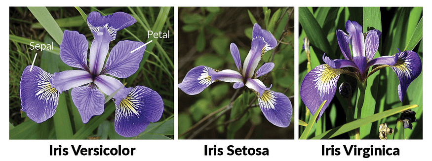

## 1. Importing Datasets

**Load a Built-in Dataset**

```r
data(iris)

head(iris)
```

|  | Sepal.Length | Sepal.Width | Petal.Length | Petal.Width | Species |
| --- | --- | --- | --- | --- | --- |
| 1 | 5.1 | 3.5 | 1.4 | 0.2 | setosa |
| 2 | 4.9 | 3.0 | 1.4 | 0.2 | setosa |
| 3 | 4.7 | 3.2 | 1.3 | 0.2 | setosa |
| 4 | 4.6 | 3.1 | 1.5 | 0.2 | setosa |
| 5 | 5.0 | 3.6 | 1.4 | 0.2 | setosa |
| 6 | 5.4 | 3.9 | 1.7 | 0.4 | setosa |

**Dataset Dimensions**

```r
dim(iris)
```

```
[1] 150   5
```

Output:

`150 5`

Meaning:

- 150 observations
- 5 variables

**View Dataset Structure**

```r
str(iris)
```

```
'data.frame':   150 obs. of  5 variables:
 $ Sepal.Length: num  5.1 4.9 4.7 4.6 5 5.4 4.6 5 4.4 4.9 ...
 $ Sepal.Width : num  3.5 3 3.2 3.1 3.6 3.9 3.4 3.4 2.9 3.1 ...
 $ Petal.Length: num  1.4 1.4 1.3 1.5 1.4 1.7 1.4 1.5 1.4 1.5 ...
 $ Petal.Width : num  0.2 0.2 0.2 0.2 0.2 0.4 0.3 0.2 0.2 0.1 ...
 $ Species     : Factor w/ 3 levels "setosa","versicolor",..: 1 1 1 1 1 1 1 1 1 1 ...
```

Output:

```r
'data.frame': 150 obs. of 5 variables:
$ Sepal.Length: num
$ Sepal.Width : num
$ Petal.Length: num
$ Petal.Width : num
$ Species     : Factor
```

## 2. Identifying Variable Types

**Display Data Types**

```r
sapply(iris, class)
```

```
Sepal.Length  Sepal.Width Petal.Length  Petal.Width      Species
   "numeric"    "numeric"    "numeric"    "numeric"     "factor"
```

Output:

```r
Sepal.Length    numeric
Sepal.Width     numeric
Petal.Length    numeric
Petal.Width     numeric
Species         factor
```

**Understanding Variable Types**

| Variable | Type |
| --- | --- |
| Sepal.Length | Numeric |
| Sepal.Width | Numeric |
| Petal.Length | Numeric |
| Petal.Width | Numeric |
| Species | Categorical (Factor) |

**Count Variable Types**

```r
table(sapply(iris, class))
```

```
 factor numeric
      1       4
```

## 3. Summary Statistics

**Summary of Entire Dataset**

```r
summary(iris)
```

```
  Sepal.Length    Sepal.Width     Petal.Length    Petal.Width
 Min.   :4.300   Min.   :2.000   Min.   :1.000   Min.   :0.100
 1st Qu.:5.100   1st Qu.:2.800   1st Qu.:1.600   1st Qu.:0.300
 Median :5.800   Median :3.000   Median :4.350   Median :1.300
 Mean   :5.843   Mean   :3.057   Mean   :3.758   Mean   :1.199
 3rd Qu.:6.400   3rd Qu.:3.300   3rd Qu.:5.100   3rd Qu.:1.800
 Max.   :7.900   Max.   :4.400   Max.   :6.900   Max.   :2.500
       Species
 setosa    :50
 versicolor:50
 virginica :50
```

Output includes:

- Min
- 1st Quartile
- Median
- Mean
- 3rd Quartile
- Max

**Summary of a Single Variable**

```r
summary(iris$Sepal.Length)
```

```
   Min. 1st Qu.  Median    Mean 3rd Qu.    Max.
  4.300   5.100   5.800   5.843   6.400   7.900
```

## 4. Measures of Central Tendency

**Mean**

```r
mean(iris$Sepal.Length)
```

```
[1] 5.843333
```

**Median**

```r
median(iris$Sepal.Length)
```

```
[1] 5.8
```

**Mode (Custom Function)**

```r
get_mode <- function(x)
{
  unique_values <- unique(x)

  unique_values[
    which.max(tabulate(match(x, unique_values)))
  ]
}

get_mode(iris$Species)
```

```
[1] setosa
Levels: setosa versicolor virginica
```

## 5. Measures of Spread

**Variance**

```r
var(iris$Sepal.Length)
```

```
[1] 0.6856935
```

**Standard Deviation**

```r
sd(iris$Sepal.Length)
```

```
[1] 0.8280661
```

**Range**

```r
range(iris$Sepal.Length)
```

```
[1] 4.3 7.9
```

**Interquartile Range (IQR)**

```r
IQR(iris$Sepal.Length)
```

```
[1] 1.3
```

## 6. Calculating Statistics for Multiple Variables

**Mean of All Numeric Variables**

```r
sapply(iris[,1:4], mean)
```

```
Sepal.Length  Sepal.Width Petal.Length  Petal.Width
    5.843333     3.057333     3.758000     1.199333
```

**Median of All Numeric Variables**

```r
sapply(iris[,1:4], median)
```

```
Sepal.Length  Sepal.Width Petal.Length  Petal.Width
        5.80         3.00         4.35         1.30
```

**Standard Deviation of All Numeric Variables**

```r
sapply(iris[,1:4], sd)
```

```
Sepal.Length  Sepal.Width Petal.Length  Petal.Width
   0.8280661    0.4358663    1.7652982    0.7622377
```

## 7. Converting Data Types

Create a sample dataset:

```r
students <- data.frame(
  ID = c("101","102","103"),
  Age = c("20","21","22"),
  CGPA = c("3.50","3.75","3.80")
)

students
```

| ID | Age | CGPA |
| --- | --- | --- |
| 101 | 20 | 3.50 |
| 102 | 21 | 3.75 |
| 103 | 22 | 3.80 |

**Check Current Types**

```r
str(students)
```

```
'data.frame':   3 obs. of  3 variables:
 $ ID  : chr  "101" "102" "103"
 $ Age : chr  "20" "21" "22"
 $ CGPA: chr  "3.50" "3.75" "3.80"
```

Output:

```r
ID   : chr
Age  : chr
CGPA : chr
```

**Convert Character to Numeric**

```r
students$Age <- as.numeric(students$Age)

students$CGPA <- as.numeric(students$CGPA)
```

**Verify Conversion**

```r
str(students)
```

```
'data.frame':   3 obs. of  3 variables:
 $ ID  : chr  "101" "102" "103"
 $ Age : num  20 21 22
 $ CGPA: num  3.5 3.75 3.8
```

Output:

```r
Age  : num
CGPA : num
```

**Convert Character to Factor**

```r
students$ID <- as.factor(students$ID)

str(students)
```

```
'data.frame':   3 obs. of  3 variables:
 $ ID  : Factor w/ 3 levels "101","102","103": 1 2 3
 $ Age : num  20 21 22
 $ CGPA: num  3.5 3.75 3.8
```

## 8. Importing Data from CSV

Create a CSV file named: `students.csv`

Contents:

| ID | Name | CGPA |
| --- | --- | --- |
| 1 | Rahim | 3.70 |
| 2 | Karim | 3.50 |
| 3 | Nabila | 3.90 |

Read file:

```r
students <- read.csv(
  "students.csv"
)

head(students)
```

|  | ID | Name | CGPA |
| --- | --- | --- | --- |
| 1 | 1 | Rahim | 3.7 |
| 2 | 2 | Karim | 3.5 |
| 3 | 3 | Nabila | 3.9 |

## Exercises

**Exercise 1**

Load the built-in dataset:

`data(mtcars)`

Find:

- Number of rows
- Number of columns
- Variable names

**Exercise 2**

For the variable:

`mtcars$mpg`

Calculate:

- Mean
- Median
- Variance
- Standard Deviation

**Exercise 3**

Display summary statistics for:

`mtcars`

**Exercise 4**

Create:

`ages <- c("18","20","22","25")`

Convert it to numeric and verify the type.

**Exercise 5**

Import a CSV file and determine:

- Dataset dimensions
- Variable types
- Summary statistics

## Important Points

- When calculating individual descriptive statistics, always remember to include na.rm = TRUE. If your column contains even a single missing value (NA), R will output NA as the result unless you explicitly tell it to ignore missing values.
- If you are asked to calculate these metrics across different groups (e.g., finding the mean salary split by department). The **dplyr** package handles this beautifully.

**Example:**

```r
library(dplyr)
grouped_stats <- my_data_csv %>%
  group_by(categorical_column) %>%
  summarise(
    Group_Mean     = mean(numeric_column, na.rm = TRUE),
    Group_Median   = median(numeric_column, na.rm = TRUE),
    Group_Variance = var(numeric_column, na.rm = TRUE),
    Group_SD       = sd(numeric_column, na.rm = TRUE),
    Sample_Count   = n() # Counts number of observations per group
  )

print(grouped_stats)
```

## Homework

Download any public CSV dataset from Kaggle, UCI Machine Learning Repository, or another source.

Perform the following:

- Import the dataset into R.
- Display the first 10 rows.
- Display dataset dimensions.
- Identify variable types.
- Generate summary statistics.
- Calculate the mean, median, variance, and standard deviation for at least one numerical variable.
- Convert at least one variable to another data type. Write a short summary (3–5 sentences) describing the dataset.